# Practical Machine Learning Course Project

Lucas Gebhart

3/22/2022

## Machine Learning Course Project Prediction Exercise

This project will use the training and test data from http://groupware.les.inf.puc-rio.br/har. It consists of a number of test subjects performing exercises correctly or incorrectly. We will use this data to test prediction models. The training data consists of 19622 rows with 160 variables. The test set has 20 observations with the same variables

```
## [1] 19622   160
```

```
## [1]  20 160
```

## Pre Processing

As we look at the data, we see a significant number of NA observations that will create issues with our algorithm. I am going to eliminate columns with greater than 90% NA. I am also going to eliminate the subject identification and time variables that make up the first seven columns of the data. Getting rid of NAs reduces us to 93 columns. Eliminating background information brings us to 86.

```
## [1] 19622    93
```

```
## [1] 19622    86
```

## Further Processing

After that previous step, I thought that I was ready to get going on building models, but when running them, I was getting errors for a number of low or zero variance variables. So I’m going to eliminate them as well. This brings us down to 53 variables.

I’ll go ahead and break my data into training and validation at this stage so that I have a dataset to predict on after training other than the testing data that is very small. So my training is 13737 obvervations, leaving the other 5885 for validation.

```
## [1] 19622    53
```

```
## [1] 13737    53
```

```
## [1] 5885   53
```

## Build some models

```r
mod_rpart <- rpart(classe ~ . , data = train, method = "class")
rpartpredict <- predict(mod_rpart, validate, type = "class")
cm_rpart<- confusionMatrix(validate$classe, rpartpredict)


mod_rf <- randomForest(classe ~ . , data = train)
rf_predict <- predict(mod_rf, validate, type = "class")
cm_rf <- confusionMatrix(validate$classe, rf_predict)


mod_svm <- svm(classe ~ ., data = train)
svmpredict <- predict(mod_svm, validate)
cm_svm <- confusionMatrix(validate$classe, svmpredict)
```

## Confusion Matrices

To make this easier to read, I’ve located each Confusion Matrix here by name and then made a quick print of just the accuracy rating. From this, we can see that the random forest model does the best job predicting based on our testing and validation data.

```r
print(cm_rpart)
```

```
## Confusion Matrix and Statistics
##
##           Reference
## Prediction    A    B    C    D    E
##          A 1496   53   45   53   27
##          B  176  685  111   85   82
##          C   28   53  811   67   67
##          D   59   78  152  580   95
##          E   20   99  126   48  789
##
## Overall Statistics
##
##                Accuracy : 0.741
##                  95% CI : (0.7296, 0.7522)
##     No Information Rate : 0.3023
##     P-Value [Acc > NIR] : < 2.2e-16
##
##                   Kappa : 0.6718
##
##  Mcnemar's Test P-Value : < 2.2e-16
##
## Statistics by Class:
##
##                      Class: A Class: B Class: C Class: D Class: E
## Sensitivity            0.8409   0.7076   0.6514  0.69628   0.7443
## Specificity            0.9566   0.9077   0.9537  0.92399   0.9393
## Pos Pred Value         0.8937   0.6014   0.7904  0.60166   0.7292
## Neg Pred Value         0.9328   0.9404   0.9107  0.94859   0.9436
## Prevalence             0.3023   0.1645   0.2116  0.14155   0.1801
## Detection Rate         0.2542   0.1164   0.1378  0.09856   0.1341
## Detection Prevalence   0.2845   0.1935   0.1743  0.16381   0.1839
## Balanced Accuracy      0.8988   0.8077   0.8025  0.81013   0.8418
```

```r
print(cm_rf)
```

```
## Confusion Matrix and Statistics
##
##           Reference
## Prediction    A    B    C    D    E
##          A 1672    1    0    0    1
##          B    7 1129    3    0    0
##          C    0    3 1023    0    0
##          D    0    0   12  950    2
##          E    0    0    4    3 1075
##
## Overall Statistics
##
##                Accuracy : 0.9939
##                  95% CI : (0.9915, 0.9957)
##     No Information Rate : 0.2853
##     P-Value [Acc > NIR] : < 2.2e-16
##
##                   Kappa : 0.9923
##
##  Mcnemar's Test P-Value : NA
##
## Statistics by Class:
##
##                      Class: A Class: B Class: C Class: D Class: E
## Sensitivity            0.9958   0.9965   0.9818   0.9969   0.9972
## Specificity            0.9995   0.9979   0.9994   0.9972   0.9985
## Pos Pred Value         0.9988   0.9912   0.9971   0.9855   0.9935
## Neg Pred Value         0.9983   0.9992   0.9961   0.9994   0.9994
## Prevalence             0.2853   0.1925   0.1771   0.1619   0.1832
## Detection Rate         0.2841   0.1918   0.1738   0.1614   0.1827
## Detection Prevalence   0.2845   0.1935   0.1743   0.1638   0.1839
## Balanced Accuracy      0.9977   0.9972   0.9906   0.9970   0.9979
```

```r
print(cm_svm)
```

```
## Confusion Matrix and Statistics
##
##           Reference
## Prediction    A    B    C    D    E
##          A 1668    1    3    0    2
##          B   73 1042   23    0    1
##          C    4   26  969   20    7
##          D    3    0   81  879    1
##          E    0    5   21   28 1028
##
## Overall Statistics
##
##                Accuracy : 0.9492
##                  95% CI : (0.9433, 0.9547)
##     No Information Rate : 0.297
##     P-Value [Acc > NIR] : < 2.2e-16
##
##                   Kappa : 0.9356
##
##  Mcnemar's Test P-Value : NA
##
## Statistics by Class:
##
##                      Class: A Class: B Class: C Class: D Class: E
## Sensitivity            0.9542   0.9702   0.8833   0.9482   0.9894
## Specificity            0.9985   0.9798   0.9881   0.9829   0.9889
## Pos Pred Value         0.9964   0.9148   0.9444   0.9118   0.9501
## Neg Pred Value         0.9810   0.9933   0.9737   0.9902   0.9977
## Prevalence             0.2970   0.1825   0.1864   0.1575   0.1766
## Detection Rate         0.2834   0.1771   0.1647   0.1494   0.1747
## Detection Prevalence   0.2845   0.1935   0.1743   0.1638   0.1839
## Balanced Accuracy      0.9764   0.9750   0.9357   0.9655   0.9891
```

```r
print(cm_rpart$overall[1])
```

```
##  Accuracy
## 0.7410365
```

```r
print(cm_rf$overall[1])
```

```
##  Accuracy
## 0.9938828
```

```r
print(cm_svm$overall[1])
```

```
##  Accuracy
## 0.9491929
```

## Model Selection and prediction

Since Random Forest did the best job predicting and was higher than 95% accuracy, I’ve decided not to combine models, So I’ll predict the category of the test data here using the rf model.

```r
bestpredict <- predict(mod_rf, testset)
print(bestpredict)
```

```
##  1  2  3  4  5  6  7  8  9 10 11 12 13 14 15 16 17 18 19 20
##  B  A  B  A  A  E  D  B  A  A  B  C  B  A  E  E  A  B  B  B
## Levels: A B C D E
```

## Including Plots

Here are some fancy graphs that I haven’t tried much to improve. For RF, we can see that the first 30 or so trees do all of the work. We should stop it there for efficiency.

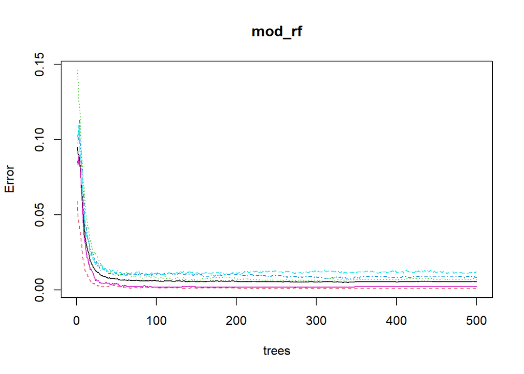

For the decision tree, we can see each split along the way as it tries to categorize. Stronger predictors are at the top.

[figure not shown]